# Logistic Regression

### Peter Ma | Dec 31st 2025

Logistic regression is effectively the classification equivalent to the linear regression problem. Instead of assuming there is a linear relationship between the data and the labels, we assume that there is a linear relationship between with the data $X$ and the **log-odds** of the labels $y$.

#### Why Log-Odds?

Reminder that the log-odds is the ratio of the probability of 2 outcomes. For example if there is probability **P** of success then the odds of success is $P/(1-P)$ but why do we care about log odds?

Well... you can't predict raw probability with a line like $y = mx+b$ because the line will eventually go above 1 or below 0, which is impossible for a probability.

But Log-Odds cover the entire number line from $-\infty$ to $+\infty$, we can set them equal to a linear equation without breaking any rules! This effectively translates the classification problem into a regression like problem.

$$\ln\left(\frac{P}{1-P}\right) = W^T X + \beta \tag{binary class.}$$

*FYI: log-odds is also called logits!*

## Formalise

Consider a binary classification problem. The goal is to define things in terms of log-odds as discussed before. $$\hat y_\theta = \sigma(W^T X + \beta)$$

We want to construct a $\sigma$ such that thats the case $$\ln\left(\frac{P}{1-P}\right) = W^T X + \beta \tag{binary class.}$$ $$\frac{P}{1-P} = \exp{W^T X + \beta \tag{binary class.}}$$

$$P = \exp{W^T X + \beta} (1-P)$$$$P = \exp{W^T X + \beta} -P\exp{W^T X + \beta} $$$$P+P\exp{W^T X + \beta} = \exp{W^T X + \beta} $$$$P(1+\exp{W^T X + \beta}) = \exp{W^T X + \beta} $$$$P = \frac{\exp{W^T X + \beta}}{1+\exp{W^T X + \beta}} $$$$\boxed{P = \frac{1}{1+\exp{-(W^T X + \beta)}}} \tag{factor and divide }$$

This is our $\sigma(z) = \frac{1}{1+\exp{-z}}$ and more famously known as the **sigmoid** function! We can generalize this to multiple classes too!

### Generalization

If we want to generalize to multi class problems we can derive the famous **softmax** function consider this generalization of log-odd...

Let us define a **reference** class. It is the class we arbitrarily choose to set as the "standard" against. A concrete example: let us classify Red, Green, or Blue ($K=3$).The probabilities must sum to 1. If I tell you $P(\text{Red}) = 0.2$ and $P(\text{Green}) = 0.5$, you automatically know that $P(\text{Blue}) = 0.3$. You don't need a separate equation to predict Blue! If we try to learn distinct weights ($W_{red}, W_{green}, W_{blue}$) for all three, the model is over-parameterized. To fix this, we pick one class—let's pick Blue—to be the "Reference Class" and force its score to be zero.

Alright so instead of one equation, we now have $K-1$ equations. We model the log-ratio of probability of class $i$ vs the reference class $K$:$$\ln \left( \frac{P(y=i)}{P(y=K)} \right) = z_i$$ We repeate the process solve for this $$\frac{P(y=i)}{P(y=K)} = e^{z_i} \implies P(y=i) = P(y=K) \cdot e^{z_i}$$ Okay but to solve a system we know that the sum of probabilities for all classes must equal 1: $$\sum_{j=1}^{K} P(y=j) = 1$$ Now we drop in our solution from before $$\sum_{j=1}^{K} \left[ P(y=K) \cdot e^{z_j} \right] = 1$$ And then we realise there is no dependence! we can factor $$P(y=K)\sum_{j=1}^{K} \left[ e^{z_j} \right] = 1$$ $$P(y=K) = \frac{1}{\sum_{j=1}^{K} \left[ e^{z_j} \right] }$$ We see that this needs to be solved for a particular class: $$\boxed{P(y=i) = \frac{1}{\sum_{j=1}^{K} e^{z_j}} \cdot e^{z_i}}$$

### Optimization Problem

If we assume the labels follow a Bernoulli distribution, the loss function is the Binary Cross Entropy (or Negative Log Likelihood):$$\boxed{\mathcal{L} = - \sum_{i} \left[ y_i \log(\hat y_i) + (1-y_i) \log(1-\hat y_i) \right]}$$ Okay lets bang this out. Unlike linear regression, we cannot solve this with a closed-form solution (like the Normal Equation) because of the non-linearity introduced by the sigmoid. However, we can optimize this using Gradient Descent.

$$\frac{\partial \mathcal{L}}{\partial \theta} = X^T (\hat y - y)$$$$\theta := \theta - \alpha \frac{\partial \mathcal{L}}{\partial \theta}$$

Okay lets implement this. I can't use any autograd calls because I haven't shown how thats implemented so I will manually compute the gradient ;)

```
Final Weights shape: (31, 1)
Test Accuracy: 99.12%
```

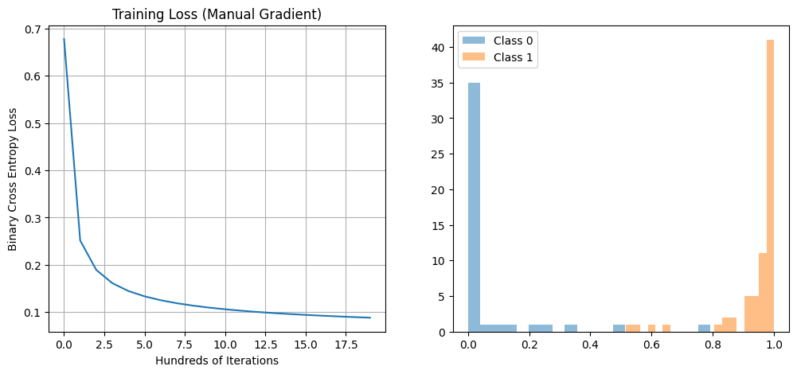

```python
import jax
import jax.numpy as jnp
import matplotlib.pyplot as plt
from sklearn.datasets import load_breast_cancer
from sklearn.model_selection import train_test_split
from sklearn.preprocessing import StandardScaler

# 1. Load & Prep Data
data = load_breast_cancer()
X, y = data.data, data.target
scaler = StandardScaler()
X = scaler.fit_transform(X)
X_train, X_test, y_train, y_test = train_test_split(X, y, test_size=0.2, random_state=42)

X_train = jnp.array(X_train)
X_test = jnp.array(X_test)
y_train = jnp.array(y_train[:, None])
y_test = jnp.array(y_test[:, None])

# 2. Bias Trick
train_ones = jnp.ones((X_train.shape[0], 1))
test_ones = jnp.ones((X_test.shape[0], 1))
X_train_aug = jnp.hstack((train_ones, X_train))
X_test_aug = jnp.hstack((test_ones, X_test))

# 3. Initialization
key = jax.random.PRNGKey(0)
W = jax.random.normal(key, (X_train_aug.shape[1], 1)) * 0.01

def predict(W, X):
    return jax.nn.sigmoid(X @ W)

# We keep this just for tracking the loss history, not for training
def loss_fn(W, X, y):
    y_pred = predict(W, X)
    eps = 1e-15
    y_pred = jnp.clip(y_pred, eps, 1 - eps)
    return -jnp.mean(y * jnp.log(y_pred) + (1 - y) * jnp.log(1 - y_pred))

# MANUAL GRADIENT UPDATE
@jax.jit
def update_step(W, X, y, learning_rate):
    N = X.shape[0]

    # 1. Forward Pass
    y_pred = predict(W, X)

    # 2. Compute Gradient Manually: (1/N) * X.T @ (y_pred - y)
    error = y_pred - y
    grads = (X.T @ error) / N

    # 3. Update
    return W - learning_rate * grads

# Training Loop
learning_rate = 0.01
epochs = 2000
loss_history = []

for i in range(epochs):
    W = update_step(W, X_train_aug, y_train, learning_rate)

    if i % 100 == 0:
        # We only call loss_fn here for logging
        current_loss = loss_fn(W, X_train_aug, y_train)
        loss_history.append(current_loss)

print(f"\nFinal Weights shape: {W.shape}")

# 4. Results
y_pred_prob = predict(W, X_test_aug)
y_pred_class = (y_pred_prob >= 0.5).astype(jnp.float32)
accuracy = jnp.mean(y_pred_class == y_test)
print(f"Test Accuracy: {accuracy:.2%}")

# 5. Plotting
plt.figure(figsize=(12, 5))
plt.subplot(1, 2, 1)
plt.plot(loss_history)
plt.xlabel("Hundreds of Iterations")
plt.ylabel("Binary Cross Entropy Loss")
plt.title("Training Loss (Manual Gradient)")
plt.grid(True)

plt.subplot(1, 2, 2)
plt.hist(y_pred_prob[y_test==0], alpha=0.5, label='Class 0', bins=20)
plt.hist(y_pred_prob[y_test==1], alpha=0.5, label='Class 1', bins=20)
plt.legend()
plt.show()
```

## Probablistic / Generative Interpretation

You might be wondering how the hell did I get the binary cross-entropy loss function? lets derive it.

First we assume our target variable $y$ (where $y \in \{0,1\}$) follows a Bernoulli distribution.Let our model's predicted probability be $\hat{y} = P(y=1|x)$.The probability mass function for a single observation is:$$P(y|x) = \begin{cases} \hat{y} & \text{if } y=1 \\ 1-\hat{y} & \text{if } y=0 \end{cases}$$As we saw before, we can compress this into a single mathematical expression:$$P(y|x) = \hat{y}^y (1-\hat{y})^{1-y}$$

Now, assume we have a dataset of $N$ independent examples. The probability of observing this exact sequence of data (the Likelihood $L$) is the product of the individual probabilities:$$L(\theta) = \prod_{i=1}^{N} P(y^{(i)}|x^{(i)})$$Substitute our compressed Bernoulli formula:$$L(\theta) = \prod_{i=1}^{N} \left[ (\hat{y}^{(i)})^{y^{(i)}} (1-\hat{y}^{(i)})^{1-y^{(i)}} \right]$$

We want to maximize this likelihood. To make the math easier (turning products into sums), we take the natural logarithm ($\ln$ or $\log$).$$\ell(\theta) = \log \left( \prod_{i=1}^{N} \left[ (\hat{y}^{(i)})^{y^{(i)}} (1-\hat{y}^{(i)})^{1-y^{(i)}} \right] \right)$$Using the log rule $\log(ab) = \log(a) + \log(b)$:$$\ell(\theta) = \sum_{i=1}^{N} \log \left[ (\hat{y}^{(i)})^{y^{(i)}} (1-\hat{y}^{(i)})^{1-y^{(i)}} \right]$$Using the log rule $\log(a^b) = b \log(a)$:$$\boxed{\ell(\theta) = \sum_{i=1}^{N} \left[ y^{(i)} \log(\hat{y}^{(i)}) + (1-y^{(i)}) \log(1-\hat{y}^{(i)}) \right]}$$ Taddaaaaaaa! :)